## Amazon Sentiment Analysis*

I am looking to buy new headphones, so I go on amazon to find some that I like. However, these days you can’t trust the reviews. So I want to find out if the overall rating matches what people actually think of the headphones.

I used a chrome extension to download all the reviews from the amazon product listing, load up my libraries, and get the data into R.

```r
library(tidyverse)
library(syuzhet)
library(tidytext)
library(ggthemr)
library(patchwork)


options(max.print = 65) # set up my  max.print for console
ggthemr("dust", type = 'outer') # graph themes

reviews <- read.csv("reviews.csv")
```

Glimpse the data and it looks normal, but some reviews say `FALSE` for `verified.purchase`

```r
glimpse(reviews)
```

```
## Rows: 5,000
## Columns: 10
## $ review.ID                            <chr> "R1DQZ2UGUUH5CK", "R2J5NW3UWDK6PZ~
## $ review.name                          <chr> " Super \"bang-for-the buck\"", "~
## $ reviewer.s.name                      <chr> "Jet Mech 1", "Sean", "Ricardo Me~
## $ reviewer.s.profile                   <chr> "https://www.amazon.com/gp/profil~
## $ review.rating                        <int> 5, 5, 5, 5, 5, 5, 5, 5, 1, 5, 4, ~
## $ review.date                          <chr> "4-Jun-18", "31-Jul-18", "9-Dec-1~
## $ review.text                          <chr> "This is an initial out-of-the bo~
## $ verified.purchase                    <lgl> FALSE, FALSE, FALSE, FALSE, FALSE~
## $ vine.customer.review.of.free.product <lgl> FALSE, FALSE, FALSE, FALSE, FALSE~
## $ images                               <chr> "", "https://images-na.ssl-images~
```

Pull out the data I care about and get a summary of the average reviews

```r
reviews <- reviews %>% select(
    review.ID, review.rating,
    review.date, review.text, verified.purchase, review.date
)
# look at average reviews
summary(reviews$review.rating)
```

```
##    Min. 1st Qu.  Median    Mean 3rd Qu.    Max.
##   1.000   4.000   5.000   4.215   5.000   5.000
```

Not bad. 5000 reviews written, 4.215 average. But earlier, we saw some reviews were unverified. So let me look more into that.

```r
# count the unverified reviews and see how the average changes with unverified reviews in mind
unveriefied_count <- reviews %>%
    filter(verified.purchase == FALSE) %>%
    count(verified.purchase)
unverified_stats <- reviews %>%
    filter(verified.purchase == FALSE) %>%
    select(review.rating) %>%
    summary(review.rating)
unverified_stats_removed <- reviews %>%
    filter(verified.purchase == TRUE) %>%
    select(review.rating) %>%
    summary(review.rating)
```

```r
unveriefied_count ## count of unverified purchases
```

```
##   verified.purchase    n
## 1             FALSE 1689
```

```r
unverified_stats ## stats of just unverified purchases
```

```
##  review.rating
##  Min.   :1.000
##  1st Qu.:5.000
##  Median :5.000
##  Mean   :4.784
##  3rd Qu.:5.000
##  Max.   :5.000
```

```r
unverified_stats_removed ##stats of everything with unverified purchases removed
```

```
##  review.rating
##  Min.   :1.000
##  1st Qu.:3.000
##  Median :5.000
##  Mean   :3.924
##  3rd Qu.:5.000
##  Max.   :5.000
```

Overall, the most used words make sense for headphone reviews. But, looking at the verified purchases after I pull out the unverified purchases, comfortable drops down a few ranks in the top 10. I also see that for unverified purchases, love makes it into the top 10, and music has a much higher position.

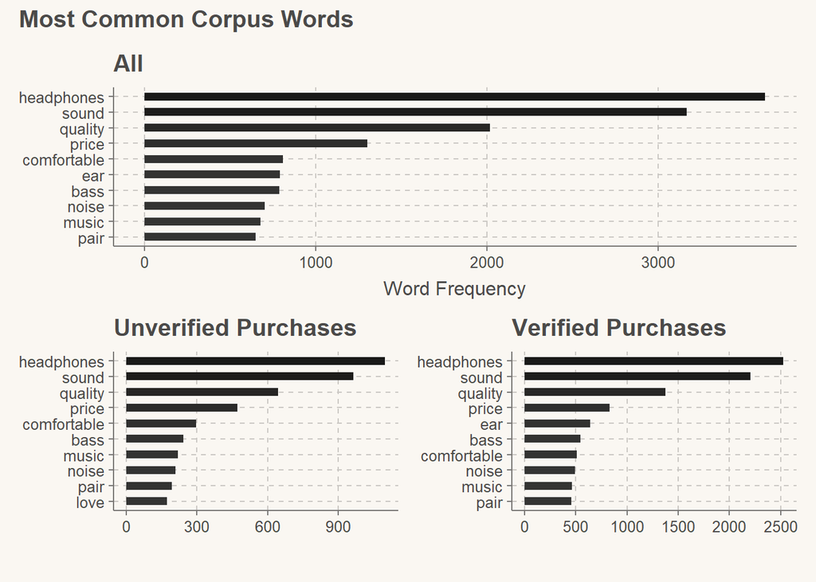

```r
# most used words
corp <- reviews %>%
    unnest_tokens(word, review.text) %>%
    filter(str_detect(word, "^[a-z]")) %>%
    anti_join(stop_words)

# most common all words
a <- corp %>%
    count(word, sort = TRUE) %>%
    top_n(10) %>%
    ggplot(aes(fct_reorder(word, n), n, fill = n)) +
    geom_col(width = 0.5) +
    coord_flip() +
    xlab(NULL) +
    coord_flip() +
    ylab("Word Frequency") +
    ggtitle("All") +
    theme(legend.position = "none")

b <- corp %>%
    filter(verified.purchase == FALSE) %>%
    count(word, sort = TRUE) %>%
    top_n(10) %>%
    ggplot(aes(fct_reorder(word, n), n, fill = n)) +
    geom_col(width = 0.5) +
    coord_flip() +
    xlab(NULL) +
    coord_flip() +
    ylab("") +
    ggtitle("Unverified Purchases") +
    theme(legend.position = "none")


c <- corp %>%
    filter(verified.purchase == TRUE) %>%
    count(word, sort = TRUE) %>%
    top_n(10) %>%
    ggplot(aes(fct_reorder(word, n), n, fill = n)) +
    geom_col(width = 0.5) +
    coord_flip() +
    xlab(NULL) +
    coord_flip() +
    ylab("") +
    ggtitle("Verified Purchases") +
    theme(legend.position = "none")


a / (b + c) + plot_annotation(
    title = "Most Common Corpus Words",
)
```

Sentiment analysis for the headphones over the years. Even though the overall pattern of the line is mostly the same. The unverified purchases have a much higher score than the verified. The score is calculated by by `ratio = positive / negative` of the words with a negative or positive sentiment in each review.

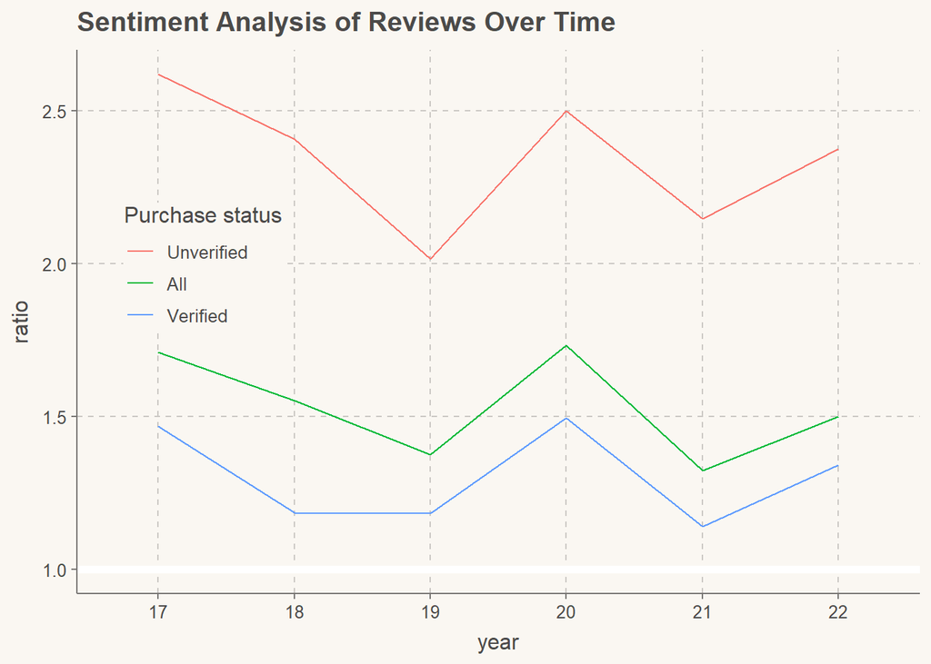

```r
# Sentiment Analysis
corp %>%
    mutate(year = format(as.POSIXct(corp$review.date,
        format = "%d-%b-%y"
    ), format = "%y")) %>%
    inner_join(get_sentiments("bing"), by = "word") %>%
    group_by(year) %>%
    count(year, sentiment) %>%
    spread(sentiment, n) %>%
    mutate(ratio = positive / negative) %>%
    ggplot(aes(x = year, y = ratio)) +
    geom_hline(yintercept = 1, color = "white", size = 2) +
    geom_line(aes(x = year, y = ratio, group = 1, color = "purple")) +
    geom_line(
        data = corp %>%
            mutate(year = format(as.POSIXct(corp$review.date,
                format = "%d-%b-%y"
            ), format = "%y")) %>%
            filter(verified.purchase == FALSE) %>%
            inner_join(get_sentiments("bing"), by = "word") %>%
            group_by(year) %>%
            count(year, sentiment) %>%
            spread(sentiment, n) %>%
            mutate(ratio = positive / negative),
        aes(year, ratio, group = 1, color = "brown")
    ) +
    geom_line(
        data = corp %>%
            mutate(year = format(as.POSIXct(corp$review.date,
                format = "%d-%b-%y"
            ), format = "%y")) %>%
            filter(verified.purchase == TRUE) %>%
            inner_join(get_sentiments("bing"), by = "word") %>%
            group_by(year) %>%
            count(year, sentiment) %>%
            spread(sentiment, n) %>%
            mutate(ratio = positive / negative),
        aes(year, ratio, group = 1, color = "red")
    ) + scale_colour_ggthemr_d() +
    ggtitle("Sentiment Analysis of Reviews Over Time") +
  scale_color_discrete(name = "Purchase status",
                       labels = c("Unverified", "All", "Verified")) +
  theme(legend.position = c(0.15, 0.6))
```

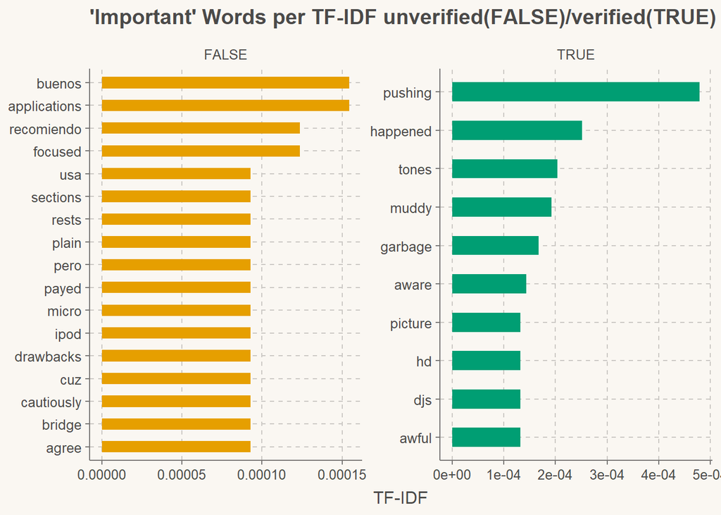

```r
# Calculating TF-IDF
corp %>%
    mutate(month_year = format(as.POSIXct(corp$review.date,
        format = "%d-%b-%y"
    ), format = "%y")) %>%
    group_by(verified.purchase) %>%
    count(word) %>%
    mutate(speech_sum = sum(n)) %>%
    bind_tf_idf(word, speech_sum, n) %>%
    top_n(10) %>%
    ggplot(aes(fct_reorder(word, tf_idf), tf_idf, fill = verified.purchase)) +
    geom_col(show.legend = FALSE, width = 0.5) +
    labs(x = NULL, y = "TF-IDF") +
    facet_wrap(~verified.purchase, ncol = 2, scales = "free") +
    coord_flip() +
    ggtitle("'Important' Words per TF-IDF unverified(FALSE)/verified(TRUE)")
```

*note: This is my first time trying sentiment analysis of any kind.